# ¿Por Qué Usar R?

Gerardo Pérez

Marzo 2021

# ¿Por qué usar R?

- Comunidad

R es utilizado por los estadísticos profesionales y académicos, además de otros analistas de datos en diversas ramas.

[figure not shown]

[figure not shown]

- Adaptabilidad

Los usuarios puedes escribir paquetes que mejoren las capacidades de R. Hay miles de paquetes disponibles para manejar diversas tareas. Esta adaptabilidad permite que haya nuevas técnicas disponibles en R años antes de que estén disponibles en software propietario.

- Flexibilidad

La modificación de procedimientos es más sencilla, a diferencia del software propietario donde el código se mantiene oculto y sólo se es capaz de modificar los parámetros ofrecidos.

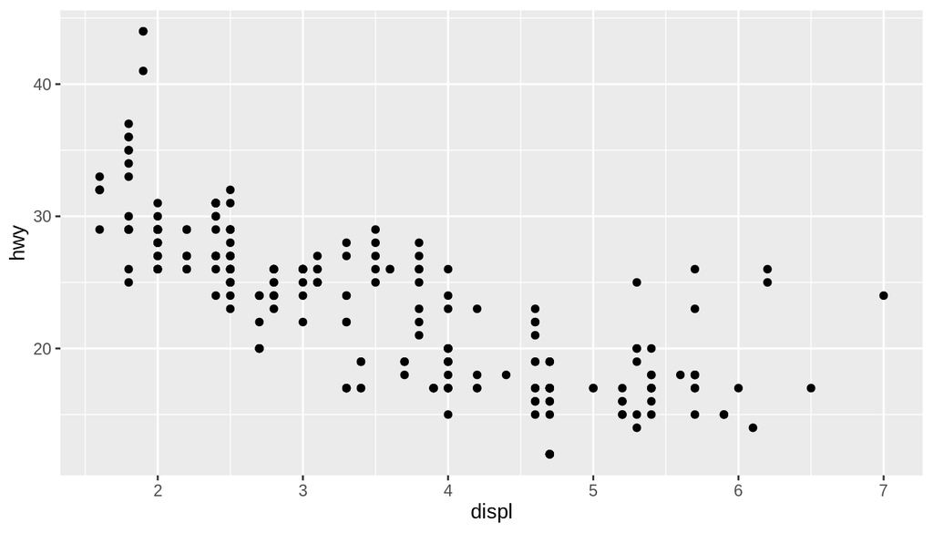

```r
ggplot(data = mpg)+
  geom_point(mapping = aes(x = displ, y = hwy))
```

Con un parámetro más (color = class) se podrá obtener un poco más de información de la visualización.

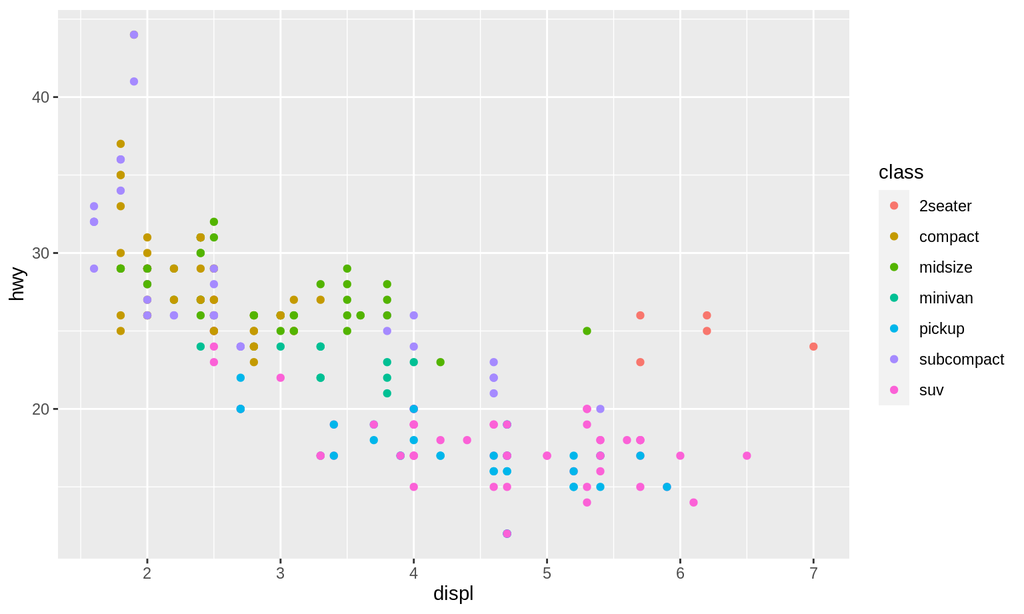

```r
ggplot(data = mpg)+
  geom_point(mapping = aes(x = displ, y = hwy, color = class))
```

- Rendimiento

R es rápido y se puede trabajar con grandes conjuntos de datos. Aunque no es el lenguaje más rápido disponible, suele ser más que suficiente para casi todo propósito.

- Fácil integración de simulación y análisis

Al realizar hipótesis en un análisis estadístico es común cuestionarse “¿qué pasaría si…?” y responder estas preguntas en R es muy sencillo.

```
##    speed dist
## 1      4    2
## 2      4   10
## 3      7    4
## 4      7   22
## 5      8   16
## 6      9   10
## 7     10   18
## 8     10   26
## 9     10   34
## 10    11   17
```

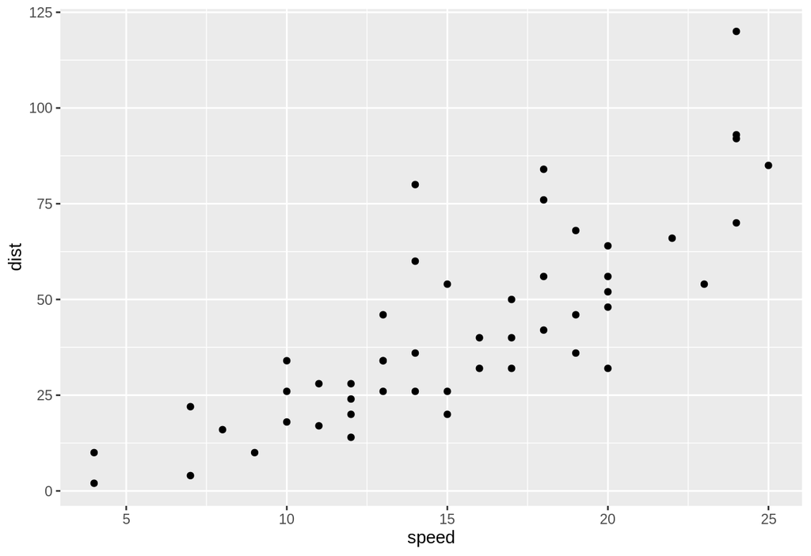

```r
ggplot(data = cars, mapping = aes(x = speed, y = dist))+
  geom_point()
```

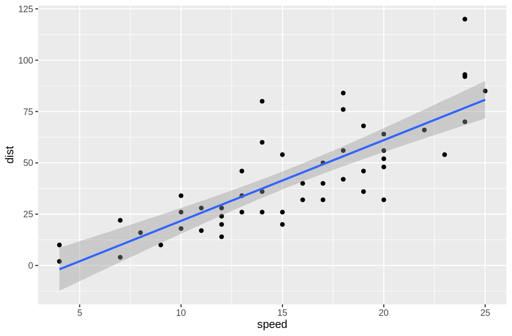

```r
ggplot(data = cars, mapping = aes(x = speed, y = dist))+
  geom_point()+
  geom_smooth(method = 'lm')
```

- Precio

R es un software libre bajo GNU. La ventaja más clara es que será gratuito, además de que por ser gratuito la comunidad será más amplia.

# Instalación

### Windows

https://www.youtube.com/watch?v=D9Bp11iZssc

### Mac OS

https://www.youtube.com/watch?v=sR-0BthRivY

### Linux

https://www.youtube.com/watch?v=3ni-jP2qEWg

# Referencias

Crowe, C. T., Montgomery, D. C., Elger, D. F., Peck, E. A., Vining, G. G., & Roberson, J. A. (2002). Introducción al análisis de regresión lineal. Alianza Editorial.

Generación Multidisciplinarias. (2020, 22 septiembre). DESCARGAR E INSTALAR R Y RSTUDIO EN MAC fácil-2021 [Vídeo]. YouTube. https://www.youtube.com/watch?v=sR-0BthRivY

Hensel Mora Ochoa. (2020, 22 enero). Cómo Descargar e Instalar R y RStudio [Vídeo]. YouTube. https://www.youtube.com/watch?v=D9Bp11iZssc

Oxford Academic (2019). 6 reasons why you should use R. Medium. URL https://medium.com/science-uncovered/6-reasons-why-you-should-use-r-38643ec98d0a

R Core Team (2021). R: A language and environment for statistical computing. R Foundation for Statistical Computing, Vienna, Austria. URL https://www.R-project.org/.

Renzo Caceres Rossi. (2020, 6 mayo). Instalando R & RStudio en Ubuntu 18.04 | Paso a Paso [Vídeo]. YouTube. https://www.youtube.com/watch?v=3ni-jP2qEWg